# R Notebook

# Testing difference in proportions -

Is the amount of women voting for Obama significantly different than the percentage of women voting for Romney?

H0: mean_women_Obama - mean_women_Rom = 0 Ha: mean_women_Obama - mean_women_Rom != 0

```r
poll <- read_csv("data/election_data.csv")
```

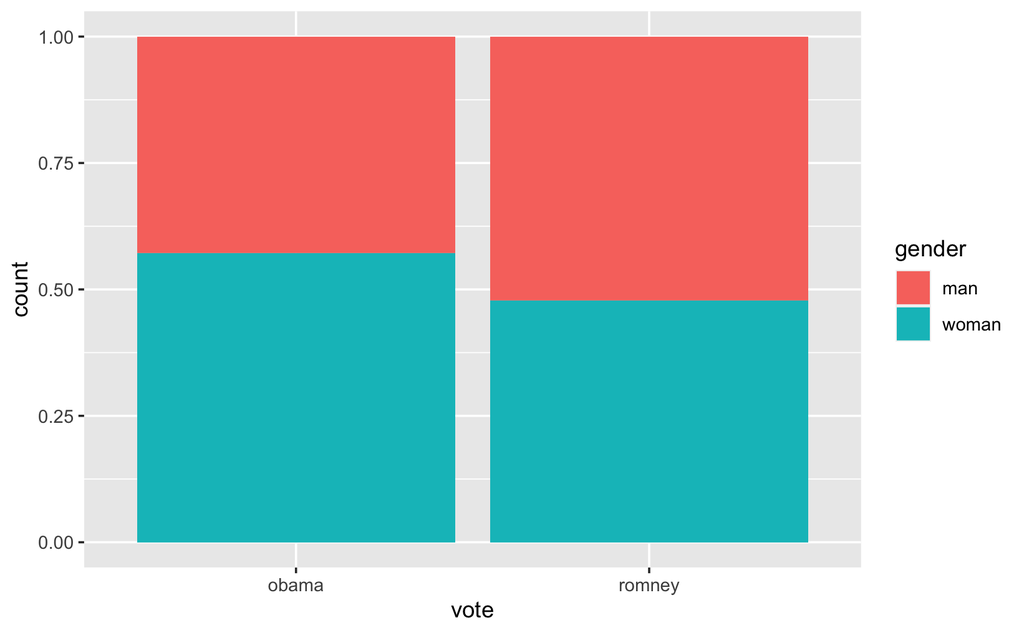

# Null

```r
null_distribution <- poll %>%
  # if this code is slow, may want to do the following
  # mutate(gender_flag = if_else(gender == "woman", 1, 0)) %>%
  # specify(gender_flag ~ vote) %>%
  specify(gender ~ vote, success = "woman") %>%
  hypothesize(null = "independence") %>%
  generate(reps = 1000, type = "permute") %>%
  # and if using gender_flag, this instead
  # calculate(stat = "diff in means", order = c("obama", "romney"))
  calculate(stat = "diff in props", order = c("obama", "romney"))
head(null_distribution)
```

| replicate | stat |
| --- | --- |
| 1 | 0.0461729692 |
| 2 | -0.0150168398 |
| 3 | -0.0244306566 |
| 4 | -0.0087409620 |
| 5 | -0.0118789009 |
| 6 | -0.0008961147 |

# Vis

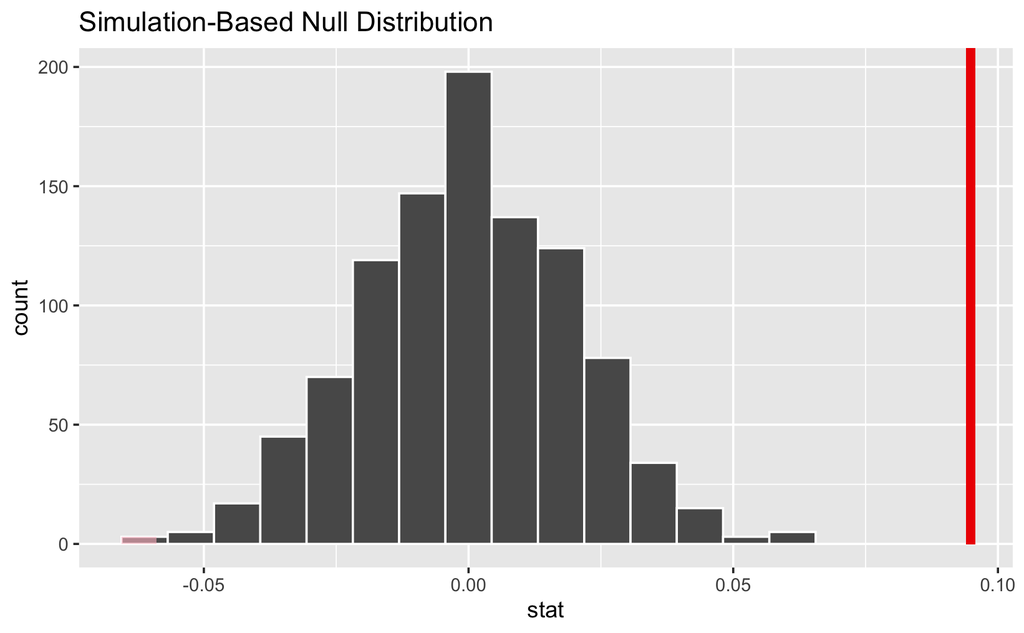

# P value

```r
get_p_value(x = null_distribution, obs_stat = observed_stat, direction = "both")
```

```
Please be cautious in reporting a p-value of 0. This result is an approximation based on the number of `reps` chosen in the `generate()` step. See `?get_p_value()` for more information.
```

| p_value |
| --- |
| 0 |

Strong evidence to reject null hypothesis, conclude that the proportion of Obama voters who are women is significantly different to the proportion of Romney voters who are women.